# Missed appointment report

# Report details

Reporting date range: **01 Jan 2009 - 01 Jan 2010**  
Date and time report generated: **29 May 2020, 13:51 CEST**  
Reporting package version: **0.0.2.0**

Comments or questions to: **his@oca.msf.org**

# Missed appointments

## Summary

Between **01 Jan 2009 - 01 Jan 2010**, a total of **57 patients** missed their appointment and have not been seen in clinic or given a treatment outcome during this period.

A description of these patients is tabulated and illustrated in the histogram below:

[output not shown]

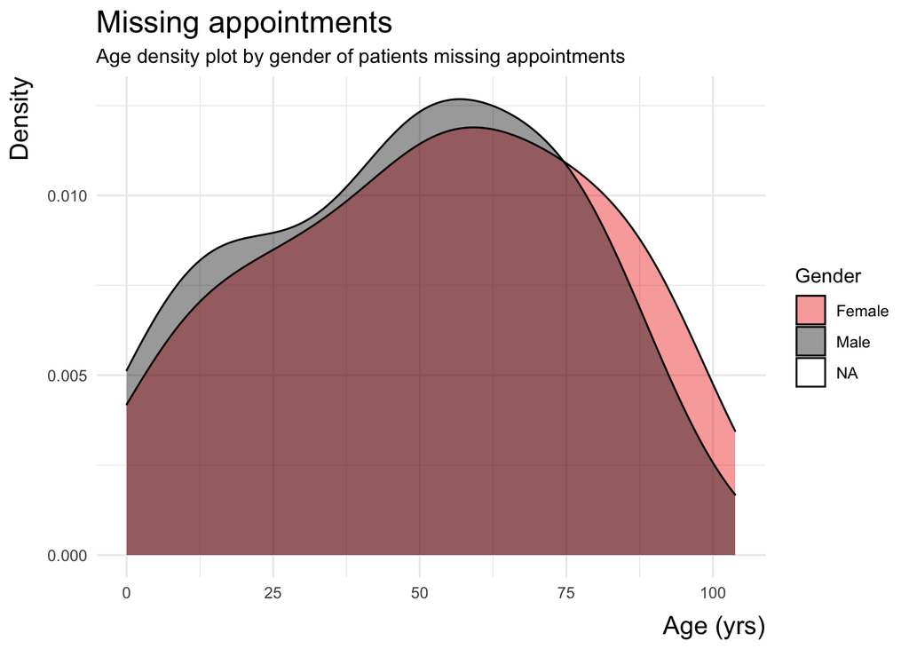

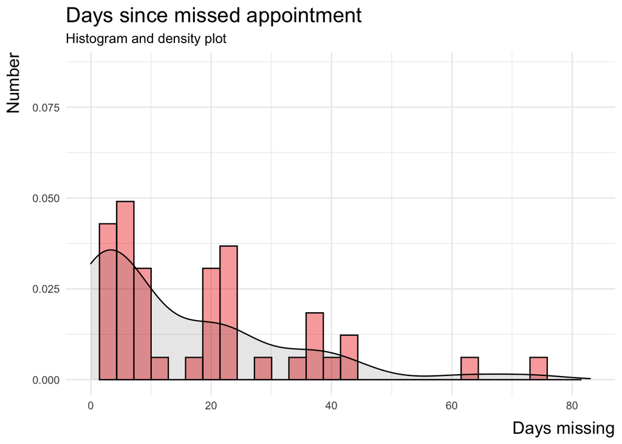

## Patient list

### Recent LTFU

#### Missed appointment in the previous 30 days

During this period, **47 patients** missed their appointments and were not discharged or seen again prior to the end of this reporting period.

| Patient ID | Missed appointment date | Days since appointment | Gender | Age on reporting date (yrs) |
| --- | --- | --- | --- | --- |
| 210 | 2009-12-08 | 24 days | Female | 77.3 |
| 144 | 2009-12-09 | 23 days | Female | 76.9 |
| 221 | 2009-12-09 | 23 days | Male | 90.1 |
| 327 | 2009-12-09 | 23 days | Male | 37.5 |
| 477 | 2009-12-10 | 22 days | Female | 26.4 |
| 726 | 2009-12-10 | 22 days | Male | 45.6 |
| 254 | 2009-12-11 | 21 days | Male | 11.2 |
| 458 | 2009-12-11 | 21 days | Male | 56.9 |
| 538 | 2009-12-13 | 19 days | Male | 24.5 |
| 808 | 2009-12-13 | 19 days | Female | 12.0 |
| 888 | 2009-12-13 | 19 days | Male | 39.7 |
| 866 | 2009-12-14 | 18 days | Female | 65.1 |
| 69 | 2009-12-20 | 12 days | Female | 14.4 |
| 488 | 2009-12-22 | 10 days | Male | 51.5 |
| 318 | 2009-12-23 | 9 days | Female | 90.8 |
| 29 | 2009-12-24 | 8 days | Male | 13.2 |
| 70 | 2009-12-24 | 8 days | Female | 31.1 |
| 627 | 2009-12-24 | 8 days | Male | 26.3 |
| 671 | 2009-12-25 | 7 days | Male | 62.3 |
| 767 | 2009-12-25 | 7 days | Male | 4.1 |
| 784 | 2009-12-25 | 7 days | Male | 77.6 |
| 367 | 2009-12-26 | 6 days | Female | 9.4 |
| 170 | 2009-12-27 | 5 days | Female | 90.1 |
| 551 | 2009-12-27 | 5 days | Female | 51.6 |
| 669 | 2009-12-27 | 5 days | Female | 50.6 |
| 918 | 2009-12-27 | 5 days | Female | 73.5 |
| 284 | 2009-12-29 | 3 days | Female | 54.8 |
| 765 | 2009-12-29 | 3 days | Male | 74.0 |
| 300 | 2009-12-30 | 2 days | Female | 61.6 |
| 665 | 2009-12-30 | 2 days | Female | 68.8 |
| 686 | 2009-12-30 | 2 days | Female | 66.3 |
| 722 | 2009-12-30 | 2 days | Female | 82.1 |
| 961 | 2009-12-30 | 2 days | Male | 50.1 |
| 27 | 2009-12-31 | 1 days | Female | 23.4 |
| 179 | 2009-12-31 | 1 days | Male | 75.1 |
| 216 | 2009-12-31 | 1 days | Male | 49.4 |
| 385 | 2009-12-31 | 1 days | Male | 4.4 |
| 618 | 2009-12-31 | 1 days | Female | 36.4 |
| 692 | 2009-12-31 | 1 days | Male | 73.4 |
| 968 | 2009-12-31 | 1 days | Female | 4.0 |
| 368 | 2010-01-01 | 0 days | ** | 86.7 |
| 490 | 2010-01-01 | 0 days | Female | 90.0 |
| 590 | 2010-01-01 | 0 days | Female | 57.2 |
| 761 | 2010-01-01 | 0 days | Female | 48.8 |
| 764 | 2010-01-01 | 0 days | Female | 46.6 |
| 780 | 2010-01-01 | 0 days | Female | 93.8 |
| 868 | 2010-01-01 | 0 days | Female | 91.8 |

### Long-terrm LTFU

#### Missed appointment beyond the previous 30 days

During this period, **10 patients** missed their appointments and were not discharged or seen again prior to the end of this reporting period.

| Patient ID | Missed appointment date | Days since appointment | Gender | Age on reporting date (yrs) |
| --- | --- | --- | --- | --- |
| 192 | 2009-10-20 | 73 days | Female | 4.2 |
| 762 | 2009-10-31 | 62 days | Female | 36.2 |
| 4 | 2009-11-19 | 43 days | Male | 84.8 |
| 361 | 2009-11-19 | 43 days | Male | 55.9 |
| 845 | 2009-11-22 | 40 days | Female | 23.9 |
| 272 | 2009-11-25 | 37 days | Female | 70.8 |
| 252 | 2009-11-26 | 36 days | Male | 19.4 |
| 593 | 2009-11-26 | 36 days | Female | 52.5 |
| 660 | 2009-11-27 | 35 days | Female | 39.3 |
| 413 | 2009-12-02 | 30 days | Male | 68.4 |

## Definitions

**Patients are included in this list if they:**

- Have been identified to have started treatment in `2_treatment_initiation_début_de_traitement` at any time prior to the end of reporting date, **and**
- Missed an appointment within the reporting period, **and**
- Have not been given an outcome that defines the end of follow-up (LTFU, death, transfer out) prior to the end of reporting date, **and**
- Have not returned to clinic prior to the end of reporting date

**Key forms:**

> New patient registration form  
> 2 Treatment Initiation _ Début de traitement  
> 4 Clin Assessment DRTB _ Évaluation Clinique TB PR  
> 4 Clin Assess Treat HIV _ Éval Clin Trait VIH  
> 4 Clin Assess Treat HCV _ Éval Clin Trait VHC  
> 6 Status change HIV _ Changement du statut VIH  
> 6 Treatment Outcome HCV _ Issue du traitement VHC  
> 6 Treatment outcome TB _ Issue du traitement TB